# second week: Introduction to R and Rstudio

Mobile Data

student name

2018-02-20 00:39:21

# تمرین سری دوم: تلفن همراه شناسی!

> با استفاده از داده های گوشی های همراه به سوالات زیر پاسخ دهید. برای رسم نمودار از پکیج ggplot2 استفاده کنید.

۱. کدام شرکت بیشترین تعداد گوشی را تولید کرده است؟ نمودار ستونی ۲۰ شرکت برتر بر حسب تعداد گوشی تولید کرده را رسم کنید.

```r
library(devtools)
library(ggplot2)
library(plyr)
library(dplyr)
library(magrittr)

mobile <- read.csv("mobile_data.csv")
mbl <- as.tbl(mobile)
colnames(mbl)
```

```
##  [1] "company"       "device"        "price"         "year"
##  [5] "announced"     "dim_length"    "dim_breadth"   "dim_thickness"
##  [9] "weight"        "display_tech"  "display_size"  "px_row"
## [13] "px_col"        "aspect_row"    "aspect_col"    "camera"
## [17] "video"         "cam_px"        "selfie"        "sel_px"
## [21] "sim_no"        "os"            "os_type"       "card_slot"
## [25] "chipset"       "cpu"           "gpu"           "ram"
## [29] "LTE"           "gps"           "radio"         "nfc"
## [33] "wlan"          "audio_jack"    "battery_mah"   "bt_v"
```

```r
mbl %>%
  group_by(company) %>%
  dplyr::summarise(count = n()) %>%
  arrange(desc(count)) %>%
  slice(1:20) -> count_com

count_com$count
```

```
##  [1] 1127  596  452  447  360  274  258  258  252  233  229  227  188  173
## [15]  160  135  126  124  120  120
```

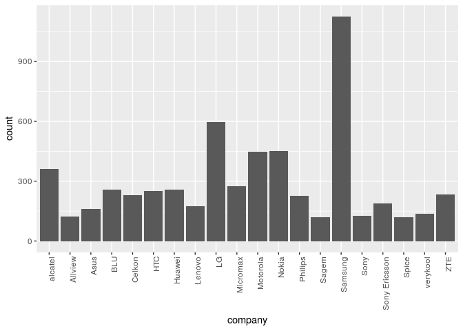

```r
ggplot() + geom_bar(data = count_com , aes(x = company, y = count ) , stat ="identity")+
  theme(axis.text.x = element_text(angle = 90, hjust = 1))
```

۲. نمودار زمانی طول عرض ضخامت و کیفیت دوربین گوشی ها را بکشید و به نمودار هر یک مدل خطی اضافه کنید.

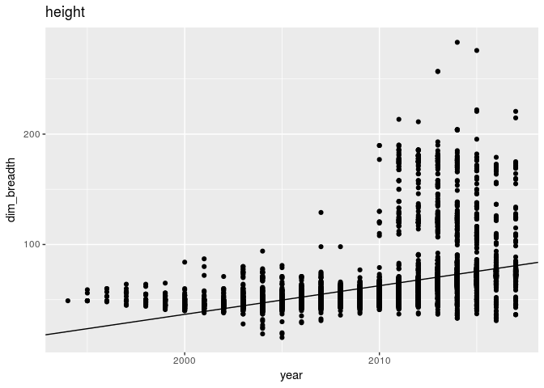

```r
p1 = ggplot(data = mobile , aes(x = year , y = dim_breadth)) +
  geom_point() + xlab("year") + ggtitle('height')
coef = coef(lm(dim_breadth ~ year,data = mbl))
p1 <- p1 + geom_abline(intercept = coef[1],slope = coef[2])
p1
```

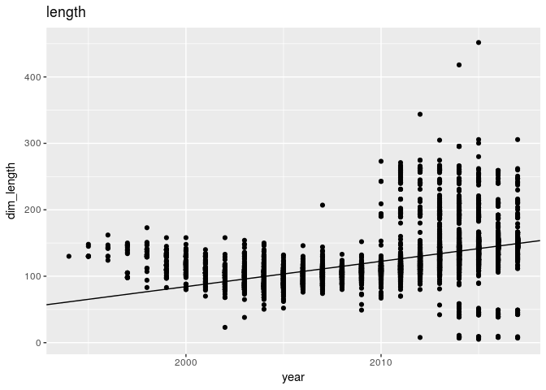

```r
p2 = ggplot(data = mobile , aes(x = year , y = dim_length)) +
  geom_point() + xlab("year") + ggtitle('length')
coef = coef(lm(dim_length ~ year,data = mbl))
p2 <- p2 + geom_abline(intercept = coef[1],slope = coef[2])
p2
```

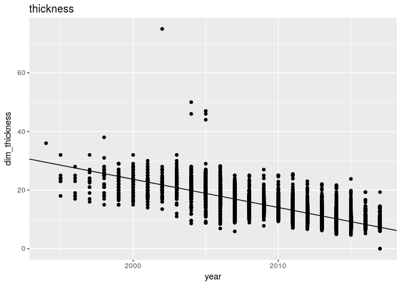

```r
p3 = ggplot(data = mobile , aes(x = year , y = dim_thickness)) +
  geom_point() + xlab("year") + ggtitle('thickness')
coef = coef(lm(dim_thickness ~ year,data = mbl))
p3 <- p3 + geom_abline(intercept = coef[1],slope = coef[2])
p3
```

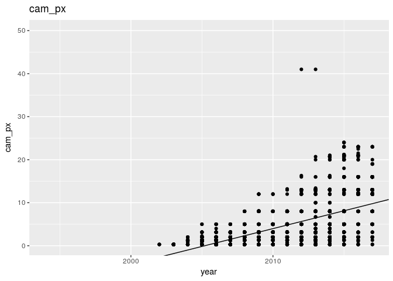

```r
p4 = ggplot(data = mobile , aes(x = year , y = cam_px)) +
  geom_point() + xlab("year") + ggtitle('cam_px')
coef = coef(lm(cam_px ~ year,data = mbl))
p4 <- p4 + geom_abline(intercept = coef[1],slope = coef[2])
p4
```

۳. نمودار ستونی متوسط قیمت گوشی بر حسب تعداد سیم کارت و دسترسی به LTE را رسم نمایید.

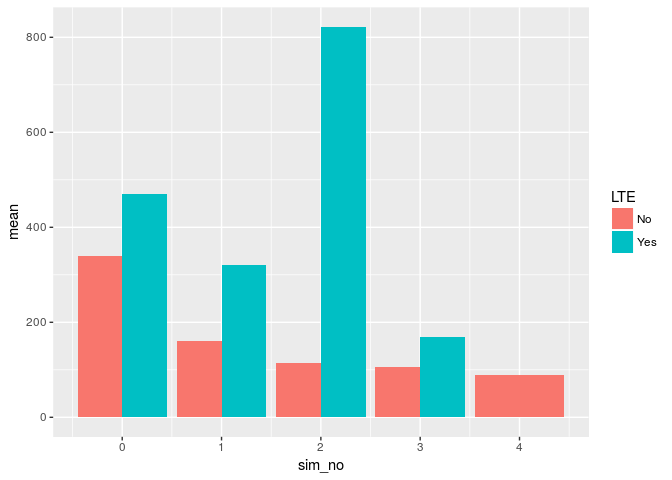

```r
mbl %>%
  group_by(LTE,sim_no) %>%
  dplyr::summarise( mean = mean(price,na.rm=T)) -> m3
p <- ggplot(m3,aes(x=sim_no,y=mean)) +geom_bar(aes(fill = LTE),stat ="identity",position
                                              = "dodge")
p
```

۴. نمودار جعبه ایی ضحامت گوشی هایی که در سال ۲۰۱۷ معرفی شده اند را برحسب اینکه کمیت جک هدفون رسم نمایید

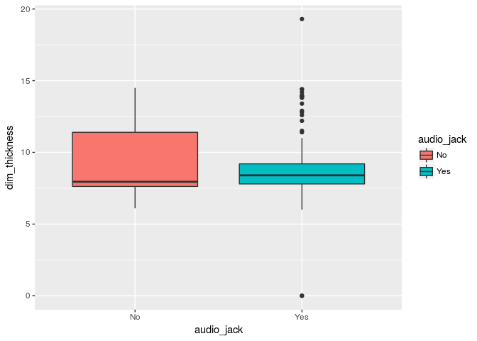

```r
mbl %>%
  filter(year == 2017) -> m4
p4  = ggplot(data = m4,aes(x = audio_jack , y = dim_thickness)) + geom_boxplot(aes(fill = audio_jack))
p4
```

۵. مفهوم ppi را در گوشی های موبایل محاسبه و هیستوگرام آن را رسم نمایید. همچنین نمودار سالانه متوسط این کمیت را بکشید. کدام گوشی بیشترین ppi را دارد؟

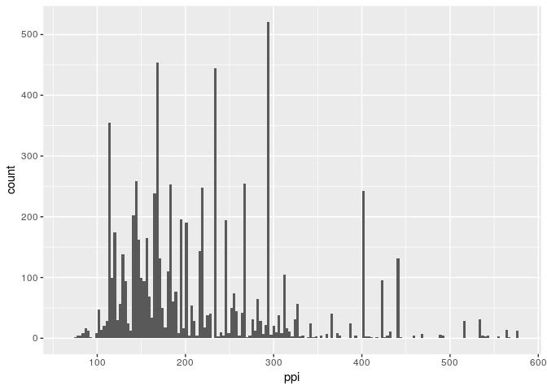

```r
mbl %>% mutate(ppi = (sqrt(px_col^2 + px_row ^2)/display_size)) -> m5
### to remove outlire :)
m5_1 = filter(m5,ppi<600)
p5_1 = ggplot(data = m5_1 , aes(x=ppi)) + geom_histogram(binwidth = 3 )
p5_1
```

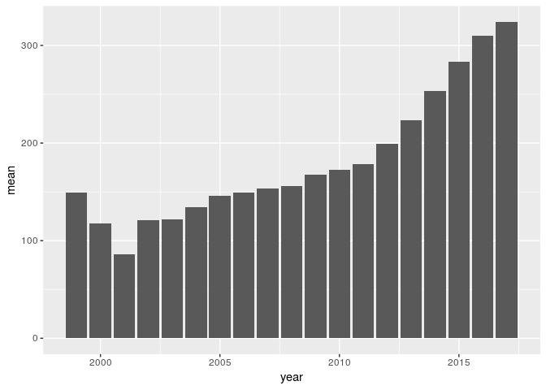

```r
###2
m5 %>%
  group_by(year) %>%
  dplyr::summarise(mean = mean(ppi, na.rm=T) ) -> m5_2

p5_2 = ggplot(data = m5_2 , aes(x=year,y=mean)) + geom_bar(stat="identity")

p5_2
```

find max

```r
##3 find max
max_id<- which.max(m5$ppi)
#### find max ppi company
m5[max_id,]$device
```

```
## [1] Xperia XZ Premium
## 8471 Levels: 10 100 101 1010 10.16G 103 105 105 (2015) ... Zylo
```

```r
#### find ppi of max ppi
m5[max_id,]$ppi
```

```
## [1] 806.9257
```

۶. در گذشته به بعضی از مدل های گوشی نوکیا **گوشکوب** گفته می شد. سعی کنید برای این مفهوم کمیتی مناسب تعریف کنید . ده گوشکوب برتر را پیدا کرده و نمودار گوشکوبیت آن را رسم نمایید.

measure for **indestructible** : i find these properties on faumes indestructible mobile like 1100 and 3310 nokia . 1- in this part I assume that for those phone that they can not be hurt they use lower density . 2- then i as i see on the best indestructible mobiles i find out that they have more Nan values in their properties as they have less property . 3- less sreen size mean less probibilty to hurt :) i use min value in all for nan values .

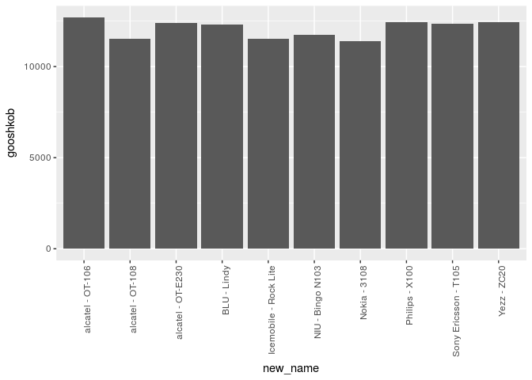

```r
#### first i will add density to tbl :)
mbl %>%
  mutate(ro = (weight / (dim_length * dim_breadth * dim_thickness))) -> mbl
mbl2 <- mbl
######### filtering

mbl2$ro[is.na(mbl2$ro)] = mean(mbl2$ro,na.rm=T)
mbl2$na_count <- apply(mbl2, 1, function(x) sum(is.na(x)))
mbl2$display_size[is.na(mbl$display_size)] = mean(mbl$display_size,na.rm=T)


mbl2 %>%
  mutate(gooshkob = na_count *  (1/ro) * (1/display_size) , new_name =paste(company,"-",device) ) %>%
  arrange(desc(gooshkob))->
  mbl2

mbl2 %>%
  select(new_name,gooshkob) %>%
  slice(1:10) -> best_goosh

ggplot(data = best_goosh,aes(x=new_name , y = gooshkob))  + geom_bar(stat = "identity")+
  theme(axis.text.x = element_text(angle = 90, hjust = 1))
```

۷. آیا تلفن همراهی وجود دارد که در آب غرق نشود؟ اگر جواب بله هست تمام گوشی های که این خاصیت را دارند بیابید. با کشیدن یک نمودار به این سوال پاسخ دهید.

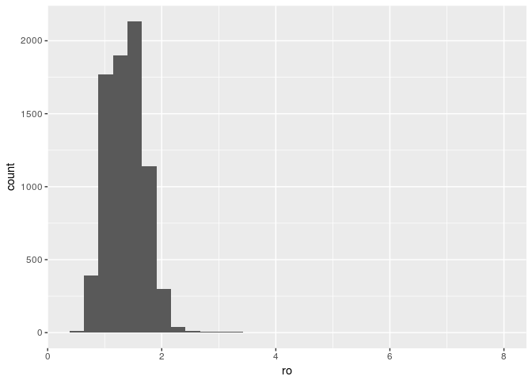

```r
mbl %>%
  mutate(ro = 1000 * (weight / (dim_length * dim_breadth * dim_thickness))) -> mbl
mbl %>%
  filter(ro <1 )-> wat_mob

ggplot(data = mbl,aes(x=ro)) + geom_histogram()
```

```r
wat_mob$device
```

```
##    [1] 2040                   OT-308                 OT-292
##    [4] OT-228                 OT-665                 OT-361
##    [7] OT-223                 OT-217                 OT-213
##   [10] OT-209                 OT-117                 OT-113
##   [13] OT-112                 OT-109                 OT-105
##   [16] OT-108                 OT-216                 OT-206
##   [19] OT-208                 OT-301                 OT-300
##   [22] OT-305                 OT-505                 OT-508A
##   [25] OT-565                 OT-106                 OT-660
##   [28] OT-383                 OT-203                 OT-103
##   [31] ELLE GlamPhone         OT-363                 Roadsign
##   [34] OT-102                 Mandarina Duck Moon    Mandarina Duck
##   [37] OT-V670                OT-V607A               OT-V270
##   [40] OT-S107                OT-C717                OT-C700A
##   [43] OT-E227                OT-E225                OT-E221
```

[output cut: 324 more lines]

as you can see in the histogram there was 1014 phone with density less than water .

۸. نمودار پراکنش حجم ذخیره سازی باطری و وزن را رسم نمایید. میزان همبستگی بین این دو کمیت را محاسبه کنید.

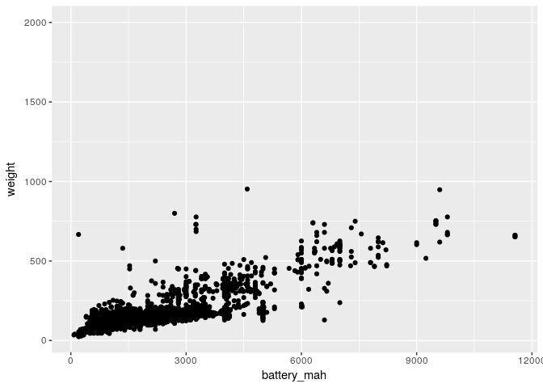

```r
ggplot(data = mbl) + geom_point(aes(x = battery_mah , y = weight))
```

```r
mbl %>%
  select(battery_mah,weight) -> sar
sar <- cor(sar , use="pairwise.complete.obs")
sar
```

```
##             battery_mah    weight
## battery_mah   1.0000000 0.8086273
## weight        0.8086273 1.0000000
```

as you can see in the scatter plot by increasing battery_mah the weight will increase . ans corralation is 0.8086 that sounds good. (as we hava nan values in both column i use pairewise.complete method that will just ignore the missing pairs of data.)

۹. قیمت پرچمداران یک برند خاص مثلا سامسونگ را بیابید و نمودار قیمت زمان و نام مدل را رسم نمایید.

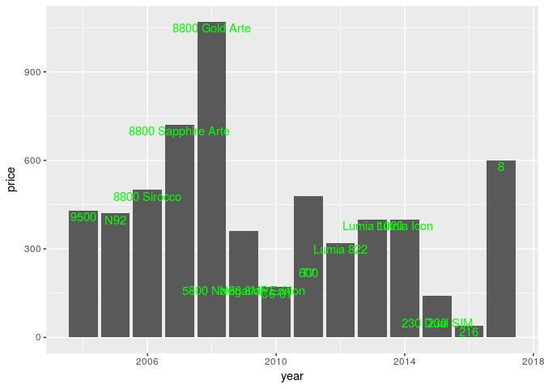

```r
mbl %>%
  filter(company == "Nokia") %>%
  group_by(year) %>%
  top_n(1,price) %>%
  ggplot (aes(x=year,y=price)) + geom_bar(stat = "identity") +
       geom_text(aes(x=year,y=price,label=device),
             hjust=0.5,vjust=1.2,color="green")
```

```r
  theme(axis.text.x = element_text(angle = 90, hjust = 1))
```

[output not shown]

۱۰. سه نمودار جالب رسم کنید و توضیح دهید چرا از نظر شما جالب است؟

1- first : i will group os and show that how much they get poplular by time .

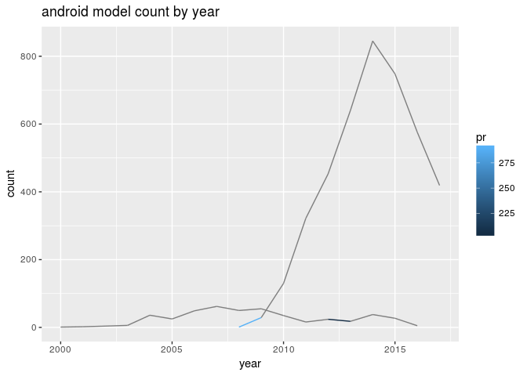

```r
mbl %>%
  filter(as.character(os_type) == "Android ") %>%
  group_by(year) %>%
  summarise(count= n() , pr = mean(price)) -> m10

mbl %>%
  filter(as.character(os_type) == "Microsoft ") %>%
  group_by(year) %>%
  summarise(count= n() , pr = mean(price)) -> m11

ggplot()  +
  geom_path(data = m10 , aes(x= year , y = count , colour = pr)) + ggtitle("android model count by year ") +  geom_path(data = m11 , aes(x= year , y = count , colour = pr))
```

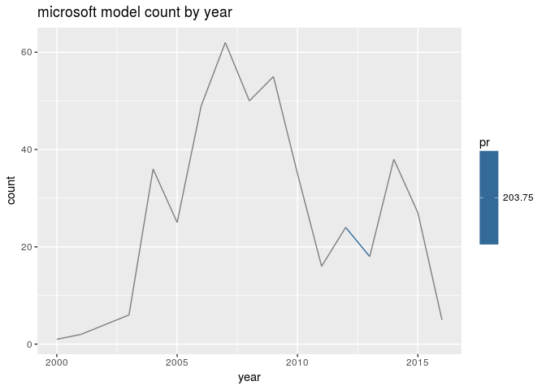

```r
ggplot()+
  geom_path(data = m11 , aes(x= year , y = count , colour = pr)) + ggtitle("microsoft model count by year ")
```

as it can be seen there model count for android increase in by contrast microsoft model decrease within 2007 to 2015 .

2- i had an hipothesis that most amount of battery_mah will used for display light that is highly correlated to display size . so i plot them .

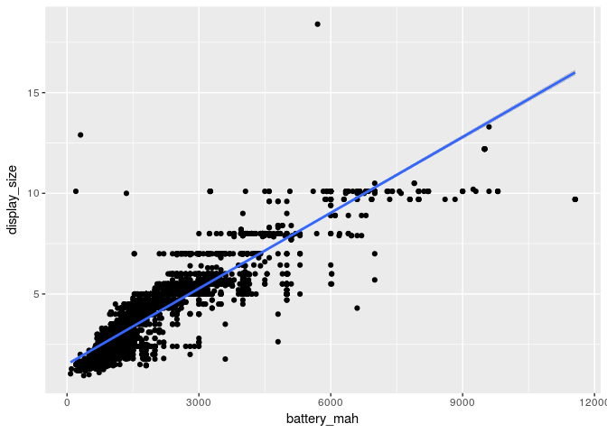

```r
ggplot()+geom_point(data = mbl, aes(x = battery_mah , y = display_size ))+
  geom_smooth(data = mbl, aes(x = battery_mah , y = display_size ),method = "lm", se = TRUE)
```

as it could be seen the hypothesis accepted .

3- i will show that the variance of adj_campx that is cam_px divided by surface of mobile (dialay_size) is lower than cam_px or theire value getting lower by time either you can not see this on cam_pxthat shows there mobile phone campany tend to increase display size when they have more cam_px .

```r
mbl %>%
  filter(company == "Nokia") %>%
  mutate(adj_campx= cam_px/display_size) %>%
  group_by(year) %>%
  summarise(cam_px = mean(cam_px,na.rm=T) , adj_campx = mean(adj_campx,na.rm=T))-> lmbl
lmbl
```

```
## # A tibble: 23 x 3
##     year  cam_px adj_campx
##    <int>   <dbl>     <dbl>
##  1  1995 NaN       NaN
##  2  1997 NaN       NaN
##  3  1998 NaN       NaN
##  4  1999 NaN       NaN
##  5  2000 NaN       NaN
##  6  2001 NaN       NaN
##  7  2002   0.300     0.143
##  8  2003   0.300     0.158
##  9  2004   0.588     0.283
## 10  2005   1.49      0.699
## # ... with 13 more rows
```

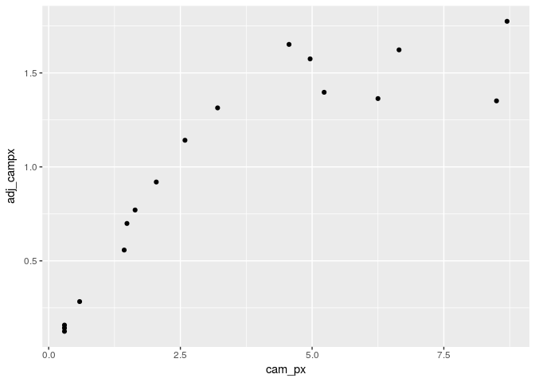

```r
ggplot(data = lmbl)+
  geom_point(aes( x =cam_px , y= adj_campx))
```

as it can be seen the is more variance in cam_px that we dont have replicated point for any space . that shows some how what i said befor.